# Common Pantry Van Analysis

Hi! This page is meant to summarize Common Pantry’s van usage. Between **November 2020** and **July 8, 2021**, the Common Pantry van has been driven **620.8** miles (and there are **1791.7** miles on the van total). We will look at the data from November through the end of June, during which the van has traveled **603** miles.

Common Pantry Van Miles per Month

Common Pantry’s van traveled the most miles in **March** and **May 2021** with over 100 miles each month. **35.5** of the **101.9** miles in March came from a trip to and from **Winnetka Congregational Church** for a donation pickup. **73.1** of the **118.5** miles driven in May resulted from traveling to and from **Matteson Prairie**.

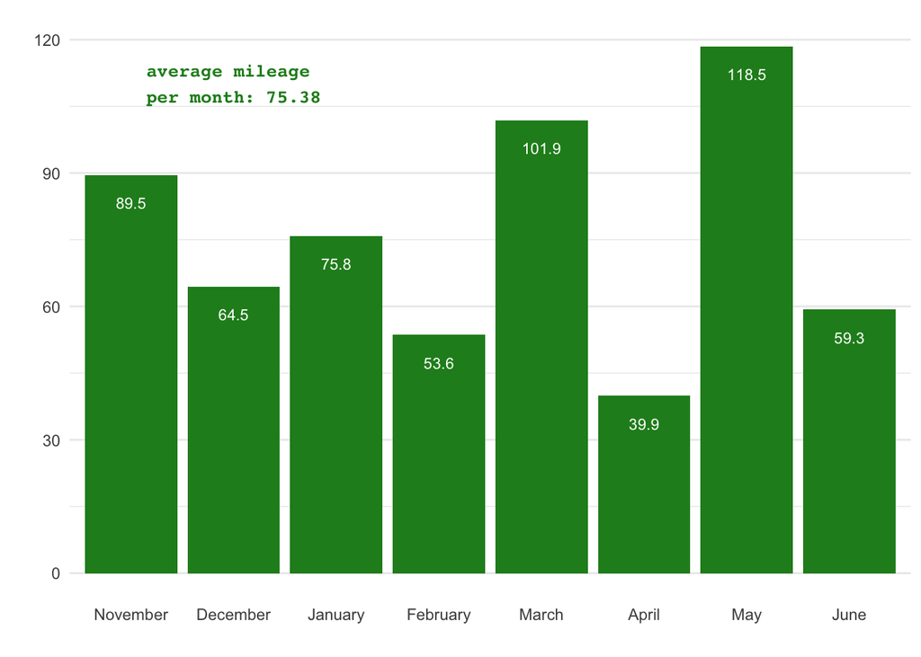

Without the trips to WCC and Matteson Prairie, the distribution of miles driven per month is adjusted below.

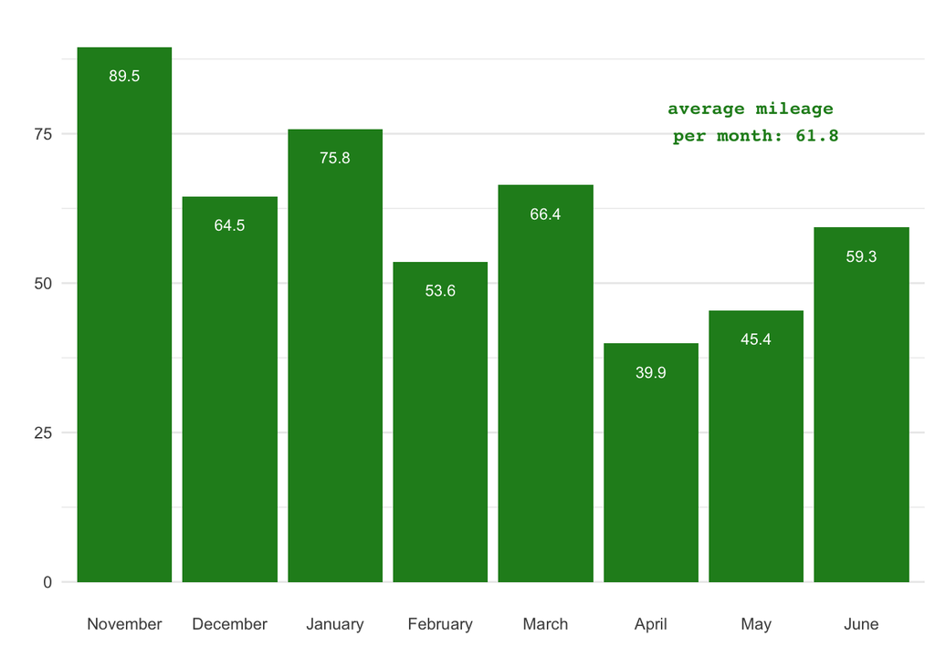

Mileage Breakdown

You may be wondering what these 600+ miles were driven for. It is broken down visually in the graph below.

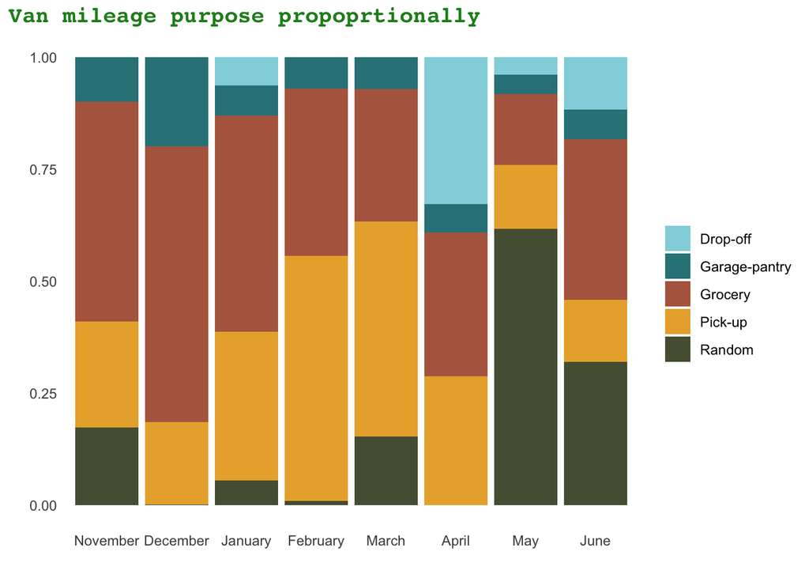

##### Here is what each category represents. Additionally, check out the table below for the exact monthly mileages to and from each destination category.

**Grocery**: miles driven to and from Aldi, Harvestime, Jewel, and Whole Foods

**Pick-up**: miles driven to pick up donations from donor homes and organizations (such as Cradles 2 Crayons, Ravenswood Elementary, Share Our Spare, and more), as well as to pick up additional items for clients (for example, First Slice, Restaurant Depot, and Metro Montrose Community Gardens).

**Random**: this counts mileage for several random trips the van was used for, including to and from Staples, Ace Hardware, Matteson Prairie, the car wash, and any trips with a missing location.

**Garage-pantry**: solely counts the mileage the van traveled between Common Pantry and the garage.

**Drop-off**: miles driven to drop of donations. This includes Salvation Army, Friendship Center, RCS, Concordia, Swedish, and more.

| Month | Grocery | Pick-up | Random | Garage-pantry | Drop-off |
| --- | --- | --- | --- | --- | --- |
| November | 43.9 | 21.2 | 15.5 | 8.9 | 0.0 |
| December | 39.7 | 11.9 | 0.1 | 12.8 | 0.0 |
| January | 36.6 | 25.1 | 4.2 | 5.1 | 4.8 |
| February | 20.1 | 29.3 | 0.5 | 3.7 | 0.0 |
| March | 30.2 | 48.9 | 15.6 | 7.2 | 0.0 |
| April | 12.8 | 11.5 | 0.0 | 2.5 | 13.1 |
| May | 18.7 | 17.0 | 73.1 | 5.2 | 4.5 |
| June | 21.3 | 8.2 | 19.0 | 3.9 | 6.9 |
| Total | 223.3 | 173.1 | 128.0 | 49.3 | 29.3 |

Mapping the van’s locations

This map shows the locations the Common Pantry van has driven between **November 2020 and July 8, 2021**. Almost all locations are shown expect for **donor houses** and a few others that I was not able to pinpoint the address of from the data.

**Using this map:**

- **Zoom in and out** using the buttons in the upper left. If it gets out of whack, just reload the website.
- **Hover over the points** to see the name of each location
- **Click on points** to see the number of times the location has been visited by the van. Locations that have been visited more than **5 times** are shown in yellow.

[interactive chart not shown]

Thanks so much for learning about Common Pantry’s van data!

Please reach out to Common Pantry with any questions on the van and/or to make a donation. With questions about this website, please contact Erin Franke at efranke@macalester.edu.